# Practical Machine Learning: Course Project

dwerbam

10/29/2019

## Description

The goal of your project is to predict the manner in which they did the exercise. This is the “classe” variable in the training set. You may use any of the other variables to predict with. You should create a report describing how you built your model, how you used cross validation, what you think the expected out of sample error is, and why you made the choices you did. You will also use your prediction model to predict 20 different test cases.

### Bootstrapping…

```r
library(dplyr)
library(caret)
library(randomForest)
library(tibble)
```

### Loads and clean up data

```r
training <- read.csv('pml-training.csv', na.strings = c("NA", ""))
```

```r
#removing all na columns
clean_train <- training %>% select_if(function(x) all(!is.na(x)))

# remove useless features that are not relevant to the prediction (first cols: user_name, etc.)
clean_train <- clean_train[,8:ncol(clean_train)]
dim(clean_train)
```

```
[1] 19622    53
```

We are left with 53 variables, and we could try here to analyze the correlation but let’s first see the performance of the model so far…

```r
set.seed(2323)
part <- createDataPartition(y=clean_train$classe, p=0.75, list=F)
split_train <- clean_train[part,]
split_test <- clean_train[-part,]

dim(split_train)
```

```
[1] 14718    53
```

```r
dim(split_test)
```

```
[1] 4904   53
```

### Creates a model and test performance with random forest

```r
## preparing cross validation
ctrl <- trainControl(method = "cv", number = 3, allowParallel = T)
mod  <- train(classe ~ ., data = split_train, method = "rf", trControl = ctrl)
mod
```

```
Random Forest

14718 samples
   52 predictor
    5 classes: 'A', 'B', 'C', 'D', 'E'

No pre-processing
Resampling: Cross-Validated (3 fold)
Summary of sample sizes: 9813, 9812, 9811
Resampling results across tuning parameters:

  mtry  Accuracy   Kappa
   2    0.9894008  0.9865920
  27    0.9883818  0.9853032
  52    0.9834900  0.9791140

Accuracy was used to select the optimal model using the largest value.
The final value used for the model was mtry = 2.
```

Accurracy looks almost 0.99. Let’s see which features are the most relevant ones:

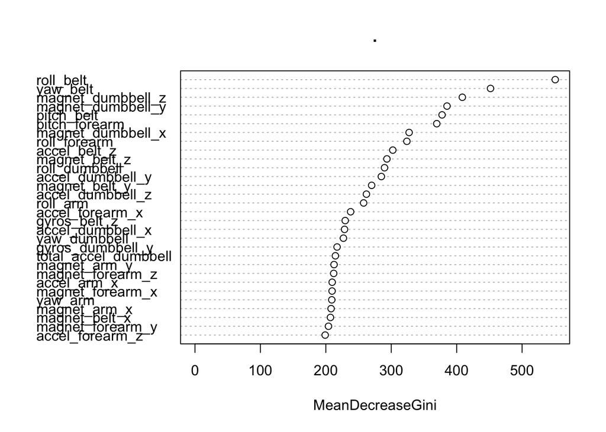

```r
mod$finalModel %>% varImpPlot
```

```r
mod$finalModel %>% varImp %>% rownames_to_column %>% arrange(desc(Overall)) %>% head(10)
```

```
             rowname  Overall
1          roll_belt 550.6690
2           yaw_belt 451.7445
3  magnet_dumbbell_z 408.6711
4  magnet_dumbbell_y 385.2361
5         pitch_belt 377.7161
6      pitch_forearm 369.5752
7  magnet_dumbbell_x 327.3075
8       roll_forearm 323.8957
9       accel_belt_z 302.3924
10     magnet_belt_z 293.3831
```

So, if we would want to compress/reduce the features we could continue from here, but that’s for another time.

### Predict new values

Using the split_test we will check accurracy of the model on new values (out of sample accurracy):

```r
pred <- predict(mod, split_test)
postResample(pred, split_test$classe)
```

```
 Accuracy     Kappa
0.9949021 0.9935510
```

```r
confusionMatrix(pred, split_test$classe)
```

```
Confusion Matrix and Statistics

          Reference
Prediction    A    B    C    D    E
         A 1395    4    0    0    0
         B    0  945    6    0    0
         C    0    0  847   10    1
         D    0    0    2  793    1
         E    0    0    0    1  899

Overall Statistics

               Accuracy : 0.9949
                 95% CI : (0.9925, 0.9967)
    No Information Rate : 0.2845
    P-Value [Acc > NIR] : < 2.2e-16

                  Kappa : 0.9936

 Mcnemar's Test P-Value : NA

Statistics by Class:

                     Class: A Class: B Class: C Class: D Class: E
Sensitivity            1.0000   0.9958   0.9906   0.9863   0.9978
Specificity            0.9989   0.9985   0.9973   0.9993   0.9998
Pos Pred Value         0.9971   0.9937   0.9872   0.9962   0.9989
Neg Pred Value         1.0000   0.9990   0.9980   0.9973   0.9995
Prevalence             0.2845   0.1935   0.1743   0.1639   0.1837
Detection Rate         0.2845   0.1927   0.1727   0.1617   0.1833
Detection Prevalence   0.2853   0.1939   0.1750   0.1623   0.1835
Balanced Accuracy      0.9994   0.9971   0.9940   0.9928   0.9988
```

### Prediction of 20:

Time to use the testing.csv for prediction of 20 different test cases:

```r
testing  <- read.csv('pml-testing.csv',  na.strings = c("NA", ""))
testing$pred <- predict(mod, testing)
testing %>% select(problem_id, user_name, pred)
```

```
   problem_id user_name pred
1           1     pedro    B
2           2    jeremy    A
3           3    jeremy    B
4           4    adelmo    A
5           5    eurico    A
6           6    jeremy    E
7           7    jeremy    D
8           8    jeremy    B
9           9  carlitos    A
10         10   charles    A
11         11  carlitos    B
12         12    jeremy    C
13         13    eurico    B
14         14    jeremy    A
15         15    jeremy    E
16         16    eurico    E
17         17     pedro    A
18         18  carlitos    B
19         19     pedro    B
20         20    eurico    B
```